# TALLAS DE ZAPATO

Brayan Aguilar

2026-03-04

Mis datos son los siguientes:
$$\Large\left(36,37,38,38,39,39,40,42 \right)$$
Tenemos que ordenarlos:
$$\Large\left(36,37,38,38,39,39,40,42),n=8,max(x)=42 \right)$$

## MEDIA

$$\Large \bar{x}=\frac{1}{n}\sum_{i=1}^{n} x_i$$

$$\Large \bar{x}=\frac{36+38+37+40+39+38+39+42}{8}$$

$$\Large \bar{x}=\frac{309}{8}$$

$$\Large \bar{x}=38.625$$
Para calcularlo mas rápidamente y verificar seria de la siguiente manera: **Codigo en r**

```r
x <- c(36,38,37,40,39,38,39,42)
mean(x)
```

```
## [1] 38.625
```

### Intepretacion

*La talla promedio del grupo es 38.6.*

## MODA

Técnicamente son los valores que se repiten:

$$\Large frecuencias: 36(1),37(1),38(2),39(2),40(1),42(1)$$

$$\Large{Moda}={38,39}$$

**Codigo en r**

```r
tab <- table(x)
moda <- as.numeric(names(tab[tab == max(tab)]))
moda
```

```
## [1] 38 39
```

### Intepretacion

*La talla de zapato mas común en todos los datos suministrado son 38 y 39*

## MEDIANA

$$\Large \tilde{x}=\frac{x_{(\frac{n}{2})}+x_{(\frac{n}{2}+1)}}{2}$$

$$\Large x_{(4)}=38,\qquad x_{(5)}=39$$

$$\Large \tilde{x}=\frac{38+39}{2}$$

$$\Large \tilde{x}=38.5$$
**Codigo en r**

```r
median(x)
```

```
## [1] 38.5
```

### Intepretacion

*La mitad del grupo tiene tallas menores o iguales a 38.5*

## MEDIA GEOMETRICA

$$\Large \Large GM=\left(\prod_{i=1}^{n}x_i\right)^{\frac{1}{n}}$$

$$\Large
GM=\left(36\cdot38\cdot37\cdot40\cdot39\cdot38\cdot39\cdot42\right)^{\frac{1}{8}}$$

$$\Large GM \approx 38.59$$
**Codigo en r**

```r
exp(mean(log(x)))
```

```
## [1] 38.5868
```

### Intepretacion

*Como vemos la media geométrica dio muy similar a la media, esto quiere decir que los datos que tengo son homogéneos, dicha media se utiliza para datos de crecimiento o valores demasiado extremo.*

## MEDIA ARMONICA

$$\Large HM=\frac{n}{\sum_{i=1}^{n}\frac{1}{x_i}}$$

$$\Large HM =
\frac{8}{\frac{1}{36}+\frac{1}{38}+\frac{1}{37}+\frac{1}{40}+\frac{1}{39}+\frac{1}{38}+\frac{1}{39}+\frac{1}{42}}$$

$$\Large HM=\frac{8}{0.2075279588}$$

$$\Large HM\approx 38.55$$
**Codigo en r**

```r
length(x) / sum(1/x)
```

```
## [1] 38.54902
```

### Intepretacion

*La media armónica es comúnmente utilizada para valores muy pequeños que tiren el promedio hacia abajo, pero paso el mismo caso de la media geométrica que el valor es muy cercano al promedio por tal razón no hay valores pequeños son muy cercanos.* ## PERCENTILES

### Percentil 25

$$\Large i=\frac{25}{100}\cdot n$$

$$\Large i=\frac{25}{100}\cdot 8$$

$$\Large i=0.25\cdot 8$$

$$\Large i=2$$
Como i es entero, tomamos el promedio entre el 2 y 3 dato:
$$\Large x_{(2)}=37,x_{(2)}=38$$
$$\Large P_{25}=\frac{37+38}{2}=37.5$$
### Intepretacion *25% del grupo tiene tallas ≤ 37.5.* ### Percentil 50
$$\Large i=\frac{50}{100}\cdot 8$$
$$\Large i=0.5\cdot 8=4$$
$$\Large x_{(4)}=38,x_{(5)}=39$$
$$\Large P_{50}=\frac{38+39}{2}=38.5$$
### Intepretacion *50% tiene tallas ≤ 38.5* ### Percentil 75
$$\Large i=\frac{75}{100}\cdot 8$$
$$\Large i=0.75\cdot 8=6$$

$$\Large x_{(6)}=39,x_{(7)}=40$$

$$\Large P_{75}=\frac{39+40}{2}=39.5$$
### Intepretacion *75% tiene tallas ≤ 39.5*

##RIQ (Recorrido Intercuantilico)
$$\Large RIQ = 39.5 - 37.5 = 2$$
### Intepretacion *Como podemos observar la mitad central solo varia en dos tallas y de acuerdo a esto mas nos confirma que es muy homogeneo* ## Bigotes
$$\Large B1 = 37.5 - 1.5(2)=37.5 - 3 = 34.5$$

$$\Large B2 = 39.5 + 1.5(2)=39.5 + 3 = 42.5$$

Bigote inferior El menor dato 34.5 = 36 Bigote superior El mayor dato 42.5 = 42

### Intepretacion

*Al observar el bigote inferior y superior con relación a mis datos en orden cubre totalmente todo por tal razón no hay datos atípicos o fuera de lo común también denominados OUTLIERS*

**Codigo en R**

```r
x_ord <- sort(x)
n <- length(x)

# Percentil 25
i25 <- (25/100) * n
if(i25 %% 1 == 0){
  P25 <- (x_ord[i25] + x_ord[i25 + 1]) / 2
} else {
  k <- floor(i25)
  d <- i25 - k
  P25 <- x_ord[k] + d * (x_ord[k+1] - x_ord[k])
}

# Percentil 50
i50 <- (50/100) * n
if(i50 %% 1 == 0){
  P50 <- (x_ord[i50] + x_ord[i50 + 1]) / 2
} else {
  k <- floor(i50)
  d <- i50 - k
  P50 <- x_ord[k] + d * (x_ord[k+1] - x_ord[k])
}

# Percentil 75
i75 <- (75/100) * n
if(i75 %% 1 == 0){
  P75 <- (x_ord[i75] + x_ord[i75 + 1]) / 2
} else {
  k <- floor(i75)
  d <- i75 - k
  P75 <- x_ord[k] + d * (x_ord[k+1] - x_ord[k])
}


# RIQ (IQR)

RIQ <- P75 - P25


# Bigotes

B1 <- P25 - 1.5 * RIQ   # Límite inferior
B2 <- P75 + 1.5 * RIQ   # Límite superior

bigote_inf <- min(x[x >= B1])
bigote_sup <- max(x[x <= B2])


# RESULTADOS

P25; P50; P75
```

```
## [1] 37.5
```

```
## [1] 38.5
```

```
## [1] 39.5
```

```r
RIQ
```

```
## [1] 2
```

```r
B1; B2
```

```
## [1] 34.5
```

```
## [1] 42.5
```

```r
bigote_inf; bigote_sup
```

```
## [1] 36
```

```
## [1] 42
```

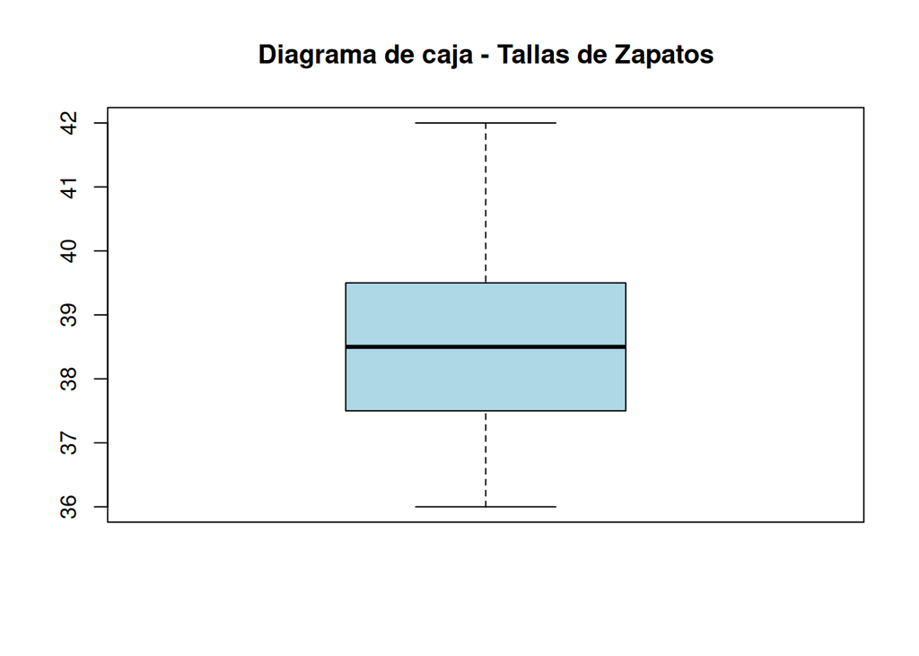

```r
# Diagrama de caja sencillo

boxplot(x, main = "Diagrama de caja - Tallas de Zapatos", col = "lightblue")
```

## RANGO

```r
rango <- max(x) - min(x)
print(rango)
```

```
## [1] 6
```

```r
media <- mean(x)
```

### Intepretacion

*Entre la talla mas grande y mas pequeña solo hay una variacion de 6 tallas*

## VARIANZA Y DESVIACION POBLACIONAL

```r
var_pop <- mean( (x - media)^2 )
sd_pop  <- sqrt(var_pop)
var_pop
```

```
## [1] 2.984375
```

```r
sd_pop
```

```
## [1] 1.727534
```

## MUESTRAL

```r
var_mues <- var(x)
sd_mues  <- sd(x)
var_mues
```

```
## [1] 3.410714
```

```r
sd_mues
```

```
## [1] 1.846812
```

### Intepretacion

*La desviación estándar me ayuda a mirar que tan alejado mis datos están del promedio y un valor menor a 2 indica muy baja dispersión.* ## Coeficiente de Variacion (CV)

```r
cv_pop  <- (sd_pop / media)*100
cv_mues <- (sd_mues / media)*100
cv_pop
```

```
## [1] 4.472581
```

```r
cv_mues
```

```
## [1] 4.78139
```

### Intepretacion

*El coeficiente de variacion nos confirma mas que son muy homogéneos ya que un valor menor al 10% indica eso, y dio resultados del 4.4 y 4.7 por ciento.* ## MOMENTOS

```r
mu2 <- mean( (x - media)^2 )
mu3 <- mean( (x - media)^3 )
mu4 <- mean( (x - media)^4 )
mu2
```

```
## [1] 2.984375
```

```r
mu3
```

```
## [1] 2.285156
```

```r
mu4
```

```
## [1] 23.51489
```

## Asimetria

```r
asimetria <- mu3 / (mu2^(3/2))
asimetria
```

```
## [1] 0.4432368
```

## Curtosis o apuntamiento

```r
curtosis <- mu4 / (mu2^2)
exceso_curtosis <- curtosis - 3
curtosis
```

```
## [1] 2.640196
```

### Interpretacion

*Con respecto al valor existe una tabla que estipula de acuerdo al puntaje obtenido, con un 0.44 nos dice que es asimétria positiva y va la cola hacia la derecha por dos tallas de valor alto que son 40 y 42* *La curtosis menor a 3 indica un tipo platicurtico es decir los datos están dispersos del centro pero muy ligeramente.*

Obtuve un poco de ayuda de la inteligencia artificial a la hora de hacer el *if*, pero lo demás trate de darlo con variables para que se mas rápido y no formular con números.